# Fitting rates of change

Prediction C and D

Anthony Davidson

2019-05-16

# Overview

This report investigates the estimation of the rates of change between seasons. The data is in a similar structure as historically used for estimation of numerical and functional responses.

# Introduction

*Generally look at thesis drafts here.*

These files are the supporting documetation to the data-wrangling code in the Beech forest manuscript here.

But there is also many other supporting resources and less formal tutorials on my [website](https://www.ssnhub.com).

# Methods

This report breaks down the parameter estimates from the bayesian hierarical model in the context of our predictions and the data we collected.

## Data

First the data for each parameter needs to be extracted and plotted. It can be hard to extract the information needed from a Bayesian output so I have left this for another vignette. For now I have just extracted the needed inforamtion for this paper.

*I Have used the following two datasets generated from the `Davidson_2019_Data_warngling.RMD` file*

| N | se.N | lcl.N | ucl.N | var | grid | trip | grid.n | trip.no | valley | control | Valley | year | month | cum.seed | seed.account.N | log.seed | valley.rep | grid.rats | Conditions | grouping.1 | grouping.2 | grouping.3 | grouping.4 | true.date | treat.six | Rats | Control | Date | Treatments | … |
| --- | --- | --- | --- | --- | --- | --- | --- | --- | --- | --- | --- | --- | --- | --- | --- | --- | --- | --- | --- | --- | --- | --- | --- | --- | --- | --- | --- | --- | --- | --- |
| 85.1859200 | 17.2583357 | 53 | 114 | N[1,1] | egl M1 | 1 | 1 | 1 | egl | control | Eglinton | 1999 | May | 590.781767 | 6.9352044 | 2.7714271 | egl | M1 | rats.removed | treat.highN | treat.highN | treat.highN | treat.highN | 1999-05-01 | egl control rats.removed | Reduced | Yes | 1999-05-01 | egl control rats.removed | … |
| 141.3464533 | 24.8136961 | 103 | 200 | N[2,1] | egl M1 | 2 | 1 | 2 | egl | control | Eglinton | 1999 | Aug | 621.339445 | 4.3958616 | 2.7933289 | egl | M1 | rats.removed | treat.highN | treat.highN | treat.highN | treat.highN | 1999-08-01 | egl control rats.removed | Reduced | Yes | 1999-08-01 | egl control rats.removed | … |
| 125.5429067 | 15.7174287 | 100 | 162 | N[3,1] | egl M1 | 3 | 1 | 3 | egl | control | Eglinton | 1999 | Nov | 631.525337 | 5.0303546 | 2.8003908 | egl | M1 | rats.removed | treat.highN | treat.highN | treat.highN | treat.highN | 1999-11-01 | egl control rats.removed | Reduced | Yes | 1999-11-01 | egl control rats.removed | … |
| 23.7692733 | 1.6613580 | 22 | 28 | N[4,1] | egl M1 | 4 | 1 | 4 | egl | control | Eglinton | 2000 | Feb | 20.371785 | 0.8570639 | 1.3090291 | egl | M1 | rats.removed | treat.lowN | treat.highN | treat.highN | treat.highN | 2000-02-01 | egl control rats.removed | Reduced | Yes | 2000-02-01 | egl control rats.removed | … |
| 89.5302533 | 18.5405013 | 57 | 125 | N[5,1] | egl M1 | 5 | 1 | 5 | egl | control | Eglinton | 2000 | May | 1324.166030 | 14.7901517 | 3.1219424 | egl | M1 | rats.removed | treat.highN | treat.highN | treat.highN | treat.highN | 2000-05-01 | egl control rats.removed | Reduced | Yes | 2000-05-01 | egl control rats.removed | … |
| 132.5741133 | 24.5620601 | 88 | 179 | N[6,1] | egl M1 | 6 | 1 | 6 | egl | control | Eglinton | 2000 | Aug | 1701.044054 | 12.8308914 | 3.2307156 | egl | M1 | rats.removed | treat.highN | treat.highN | treat.highN | treat.highN | 2000-08-01 | egl control rats.removed | Reduced | Yes | 2000-08-01 | egl control rats.removed | … |
| 122.0759400 | 18.1190611 | 93 | 164 | N[7,1] | egl M1 | 7 | 1 | 7 | egl | control | Eglinton | 2000 | Nov | 1716.322893 | 14.0594690 | 3.2345990 | egl | M1 | rats.removed | treat.highN | treat.highN | treat.highN | treat.highN | 2000-11-01 | egl control rats.removed | Reduced | Yes | 2000-11-01 | egl control rats.removed | … |
| 31.7279867 | 4.5500564 | 25 | 43 | N[8,1] | egl M1 | 8 | 1 | 8 | egl | control | Eglinton | 2001 | Feb | 0.000000 | 0.0000000 | 0.0000000 | egl | M1 | rats.removed | treat.lowN | treat.highN | treat.lowN | treat.lowN | 2001-02-01 | egl control rats.removed | Reduced | Yes | 2001-02-01 | egl control rats.removed | … |
| 17.7766000 | 3.4972180 | 13 | 26 | N[9,1] | egl M1 | 9 | 1 | 9 | egl | control | Eglinton | 2001 | May | 0.000000 | 0.0000000 | 0.0000000 | egl | M1 | rats.removed | treat.lowN | treat.highN | treat.lowN | treat.lowN | 2001-05-01 | egl control rats.removed | Reduced | Yes | 2001-05-01 | egl control rats.removed | … |
| 1.7254933 | 1.4848549 | 0 | 5 | N[10,1] | egl M1 | 10 | 1 | 10 | egl | control | Eglinton | 2001 | Aug | 0.000000 | 0.0000000 | 0.0000000 | egl | M1 | rats.removed | treat.lowN | treat.lowN | treat.lowN | treat.lowN | 2001-08-01 | egl control rats.removed | Reduced | Yes | 2001-08-01 | egl control rats.removed | … |

[output cut: 134 more lines]

### Reduce dataset

| N | lcl.N | ucl.N | var | grid | Control | Valley | trip | grid.n |
| --- | --- | --- | --- | --- | --- | --- | --- | --- |
| 85.1859200 | 53 | 114 | N[1,1] | egl M1 | Yes | Eglinton | 1 | 1 |
| 141.3464533 | 103 | 200 | N[2,1] | egl M1 | Yes | Eglinton | 2 | 1 |
| 125.5429067 | 100 | 162 | N[3,1] | egl M1 | Yes | Eglinton | 3 | 1 |
| 23.7692733 | 22 | 28 | N[4,1] | egl M1 | Yes | Eglinton | 4 | 1 |
| 89.5302533 | 57 | 125 | N[5,1] | egl M1 | Yes | Eglinton | 5 | 1 |
| 132.5741133 | 88 | 179 | N[6,1] | egl M1 | Yes | Eglinton | 6 | 1 |
| 122.0759400 | 93 | 164 | N[7,1] | egl M1 | Yes | Eglinton | 7 | 1 |
| 31.7279867 | 25 | 43 | N[8,1] | egl M1 | Yes | Eglinton | 8 | 1 |
| 17.7766000 | 13 | 26 | N[9,1] | egl M1 | Yes | Eglinton | 9 | 1 |
| 1.7254933 | 0 | 5 | N[10,1] | egl M1 | Yes | Eglinton | 10 | 1 |

[output cut: 134 more lines]

### Wrangling

| N | se.N | lcl.N | ucl.N | var | grid | trip | grid.n | trip.no | valley | control | Valley | year | month | cum.seed | seed.account.N | log.seed | valley.rep | grid.rats | Conditions | grouping.1 | grouping.2 | grouping.3 | grouping.4 | true.date | treat.six | Rats | Control | Date | Treatments | … |
| --- | --- | --- | --- | --- | --- | --- | --- | --- | --- | --- | --- | --- | --- | --- | --- | --- | --- | --- | --- | --- | --- | --- | --- | --- | --- | --- | --- | --- | --- | --- |
| 85.1859200 | 17.2583357 | 53 | 114 | N[1,1] | egl M1 | 1 | 1 | 1 | egl | control | Eglinton | 1999 | May | 590.781767 | 6.9352044 | 2.7714271 | egl | M1 | rats.removed | treat.highN | treat.highN | treat.highN | treat.highN | 1999-05-01 | egl control rats.removed | Reduced | Yes | 1999-05-01 | egl control rats.removed | … |
| 141.3464533 | 24.8136961 | 103 | 200 | N[2,1] | egl M1 | 2 | 1 | 2 | egl | control | Eglinton | 1999 | Aug | 621.339445 | 4.3958616 | 2.7933289 | egl | M1 | rats.removed | treat.highN | treat.highN | treat.highN | treat.highN | 1999-08-01 | egl control rats.removed | Reduced | Yes | 1999-08-01 | egl control rats.removed | … |
| 125.5429067 | 15.7174287 | 100 | 162 | N[3,1] | egl M1 | 3 | 1 | 3 | egl | control | Eglinton | 1999 | Nov | 631.525337 | 5.0303546 | 2.8003908 | egl | M1 | rats.removed | treat.highN | treat.highN | treat.highN | treat.highN | 1999-11-01 | egl control rats.removed | Reduced | Yes | 1999-11-01 | egl control rats.removed | … |
| 23.7692733 | 1.6613580 | 22 | 28 | N[4,1] | egl M1 | 4 | 1 | 4 | egl | control | Eglinton | 2000 | Feb | 20.371785 | 0.8570639 | 1.3090291 | egl | M1 | rats.removed | treat.lowN | treat.highN | treat.highN | treat.highN | 2000-02-01 | egl control rats.removed | Reduced | Yes | 2000-02-01 | egl control rats.removed | … |
| 89.5302533 | 18.5405013 | 57 | 125 | N[5,1] | egl M1 | 5 | 1 | 5 | egl | control | Eglinton | 2000 | May | 1324.166030 | 14.7901517 | 3.1219424 | egl | M1 | rats.removed | treat.highN | treat.highN | treat.highN | treat.highN | 2000-05-01 | egl control rats.removed | Reduced | Yes | 2000-05-01 | egl control rats.removed | … |
| 132.5741133 | 24.5620601 | 88 | 179 | N[6,1] | egl M1 | 6 | 1 | 6 | egl | control | Eglinton | 2000 | Aug | 1701.044054 | 12.8308914 | 3.2307156 | egl | M1 | rats.removed | treat.highN | treat.highN | treat.highN | treat.highN | 2000-08-01 | egl control rats.removed | Reduced | Yes | 2000-08-01 | egl control rats.removed | … |
| 122.0759400 | 18.1190611 | 93 | 164 | N[7,1] | egl M1 | 7 | 1 | 7 | egl | control | Eglinton | 2000 | Nov | 1716.322893 | 14.0594690 | 3.2345990 | egl | M1 | rats.removed | treat.highN | treat.highN | treat.highN | treat.highN | 2000-11-01 | egl control rats.removed | Reduced | Yes | 2000-11-01 | egl control rats.removed | … |
| 31.7279867 | 4.5500564 | 25 | 43 | N[8,1] | egl M1 | 8 | 1 | 8 | egl | control | Eglinton | 2001 | Feb | 0.000000 | 0.0000000 | 0.0000000 | egl | M1 | rats.removed | treat.lowN | treat.highN | treat.lowN | treat.lowN | 2001-02-01 | egl control rats.removed | Reduced | Yes | 2001-02-01 | egl control rats.removed | … |
| 17.7766000 | 3.4972180 | 13 | 26 | N[9,1] | egl M1 | 9 | 1 | 9 | egl | control | Eglinton | 2001 | May | 0.000000 | 0.0000000 | 0.0000000 | egl | M1 | rats.removed | treat.lowN | treat.highN | treat.lowN | treat.lowN | 2001-05-01 | egl control rats.removed | Reduced | Yes | 2001-05-01 | egl control rats.removed | … |
| 1.7254933 | 1.4848549 | 0 | 5 | N[10,1] | egl M1 | 10 | 1 | 10 | egl | control | Eglinton | 2001 | Aug | 0.000000 | 0.0000000 | 0.0000000 | egl | M1 | rats.removed | treat.lowN | treat.lowN | treat.lowN | treat.lowN | 2001-08-01 | egl control rats.removed | Reduced | Yes | 2001-08-01 | egl control rats.removed | … |

[output cut: 134 more lines]

#### Extracting rates from model outputs

| N | se.N | lcl.N | ucl.N | var | grid | trip | grid.n | trip.no | valley | control | Valley | year | month | cum.seed | seed.account.N | log.seed | valley.rep | grid.rats | Conditions | grouping.1 | grouping.2 | grouping.3 | grouping.4 | true.date | treat.six | Rats | Control | Date | Treatments | … |
| --- | --- | --- | --- | --- | --- | --- | --- | --- | --- | --- | --- | --- | --- | --- | --- | --- | --- | --- | --- | --- | --- | --- | --- | --- | --- | --- | --- | --- | --- | --- |
| 85.1859200 | 17.2583357 | 53 | 114 | N[1,1] | egl M1 | 1 | 1 | 1 | egl | control | Eglinton | 1999 | May | 590.781767 | 6.9352044 | 2.7714271 | egl | M1 | rats.removed | treat.highN | treat.highN | treat.highN | treat.highN | 1999-05-01 | egl control rats.removed | Reduced | Yes | 1999-05-01 | egl control rats.removed | … |
| 141.3464533 | 24.8136961 | 103 | 200 | N[2,1] | egl M1 | 2 | 1 | 2 | egl | control | Eglinton | 1999 | Aug | 621.339445 | 4.3958616 | 2.7933289 | egl | M1 | rats.removed | treat.highN | treat.highN | treat.highN | treat.highN | 1999-08-01 | egl control rats.removed | Reduced | Yes | 1999-08-01 | egl control rats.removed | … |
| 125.5429067 | 15.7174287 | 100 | 162 | N[3,1] | egl M1 | 3 | 1 | 3 | egl | control | Eglinton | 1999 | Nov | 631.525337 | 5.0303546 | 2.8003908 | egl | M1 | rats.removed | treat.highN | treat.highN | treat.highN | treat.highN | 1999-11-01 | egl control rats.removed | Reduced | Yes | 1999-11-01 | egl control rats.removed | … |
| 23.7692733 | 1.6613580 | 22 | 28 | N[4,1] | egl M1 | 4 | 1 | 4 | egl | control | Eglinton | 2000 | Feb | 20.371785 | 0.8570639 | 1.3090291 | egl | M1 | rats.removed | treat.lowN | treat.highN | treat.highN | treat.highN | 2000-02-01 | egl control rats.removed | Reduced | Yes | 2000-02-01 | egl control rats.removed | … |
| 89.5302533 | 18.5405013 | 57 | 125 | N[5,1] | egl M1 | 5 | 1 | 5 | egl | control | Eglinton | 2000 | May | 1324.166030 | 14.7901517 | 3.1219424 | egl | M1 | rats.removed | treat.highN | treat.highN | treat.highN | treat.highN | 2000-05-01 | egl control rats.removed | Reduced | Yes | 2000-05-01 | egl control rats.removed | … |
| 132.5741133 | 24.5620601 | 88 | 179 | N[6,1] | egl M1 | 6 | 1 | 6 | egl | control | Eglinton | 2000 | Aug | 1701.044054 | 12.8308914 | 3.2307156 | egl | M1 | rats.removed | treat.highN | treat.highN | treat.highN | treat.highN | 2000-08-01 | egl control rats.removed | Reduced | Yes | 2000-08-01 | egl control rats.removed | … |
| 122.0759400 | 18.1190611 | 93 | 164 | N[7,1] | egl M1 | 7 | 1 | 7 | egl | control | Eglinton | 2000 | Nov | 1716.322893 | 14.0594690 | 3.2345990 | egl | M1 | rats.removed | treat.highN | treat.highN | treat.highN | treat.highN | 2000-11-01 | egl control rats.removed | Reduced | Yes | 2000-11-01 | egl control rats.removed | … |
| 31.7279867 | 4.5500564 | 25 | 43 | N[8,1] | egl M1 | 8 | 1 | 8 | egl | control | Eglinton | 2001 | Feb | 0.000000 | 0.0000000 | 0.0000000 | egl | M1 | rats.removed | treat.lowN | treat.highN | treat.lowN | treat.lowN | 2001-02-01 | egl control rats.removed | Reduced | Yes | 2001-02-01 | egl control rats.removed | … |
| 17.7766000 | 3.4972180 | 13 | 26 | N[9,1] | egl M1 | 9 | 1 | 9 | egl | control | Eglinton | 2001 | May | 0.000000 | 0.0000000 | 0.0000000 | egl | M1 | rats.removed | treat.lowN | treat.highN | treat.lowN | treat.lowN | 2001-05-01 | egl control rats.removed | Reduced | Yes | 2001-05-01 | egl control rats.removed | … |
| 1.7254933 | 1.4848549 | 0 | 5 | N[10,1] | egl M1 | 10 | 1 | 10 | egl | control | Eglinton | 2001 | Aug | 0.000000 | 0.0000000 | 0.0000000 | egl | M1 | rats.removed | treat.lowN | treat.lowN | treat.lowN | treat.lowN | 2001-08-01 | egl control rats.removed | Reduced | Yes | 2001-08-01 | egl control rats.removed | … |

[output cut: 134 more lines]

#### Parameter dataset

| Valley | Control | month | dat.seed.mean | dat.rat.mean | dat.mice.min | dat.seed.min | dat.rat.min | dat.mice.max | dat.seed.max | dat.rat.max |
| --- | --- | --- | --- | --- | --- | --- | --- | --- | --- | --- |
| Eglinton | Yes | Aug | 2.0064741 | 1.750000 | 1.4344200 | 0 | 1 | 251.787493 | 3.517202 | NA |
| Eglinton | Yes | Feb | 0.4730018 | 5.500000 | 0.9671600 | 0 | 1 | 46.925373 | 1.485120 | NA |
| Eglinton | Yes | May | 1.5706454 | 2.875000 | 0.5977067 | 0 | 1 | 89.530253 | 3.422972 | NA |
| Eglinton | Yes | Nov | 2.0113793 | 2.000000 | 0.5596733 | 0 | 1 | 145.631960 | 3.529791 | NA |
| Hollyford | No | Aug | 1.3275835 | 5.375000 | 1.2033133 | 0 | 1 | 95.051800 | 3.191269 | NA |
| Hollyford | No | Feb | 0.7074351 | 4.625000 | 5.8326667 | 0 | 1 | 49.286380 | 1.962242 | 17 |
| Hollyford | No | May | 1.1227400 | 3.769231 | 0.4286200 | 0 | 1 | 95.169220 | 3.126925 | NA |
| Hollyford | No | Nov | 1.4508510 | 4.500000 | 0.4812667 | 0 | 1 | 98.039353 | 3.198331 | NA |
| Hollyford | Yes | Aug | 1.8990718 | 3.666667 | 2.3225667 | 0 | 1 | 22.360880 | 3.375355 | NA |
| Hollyford | Yes | Feb | 0.3381981 | 2.400000 | 0.5281533 | 0 | 1 | 25.951187 | 2.029188 | NA |

[output cut: 2 more lines]

##### Reconstructing parameter dataset

```
Observations: 48
Variables: 6
$ mean.b   <dbl> 0.46081204, -0.25878996, -0.16741136, -0.51423246, -0...
$ Control  <chr> "control", "no control", "control", "control", "no co...
$ Valley   <chr> "egl", "hol", "hol", "egl", "hol", "hol", "egl", "hol...
$ month    <chr> "Feb", "Feb", "Feb", "May", "May", "May", "Aug", "Aug...
$ para     <fct> Intercept, Intercept, Intercept, Intercept, Intercept...
$ Estimate <dbl> 0.46081204, -0.25878996, -0.16741136, -0.51423246, -0...
```

### Output datasets for modelling

- Parameter estimates: *n =* **48**
- Rate of change: *n =* **136**
- Abundance *n =* **144**

# Plots

Overall there are many combinations of plots that can be produced from a bayesian hierarichal model.

## Seed by month

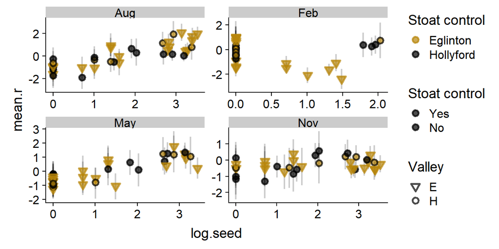

## All May data

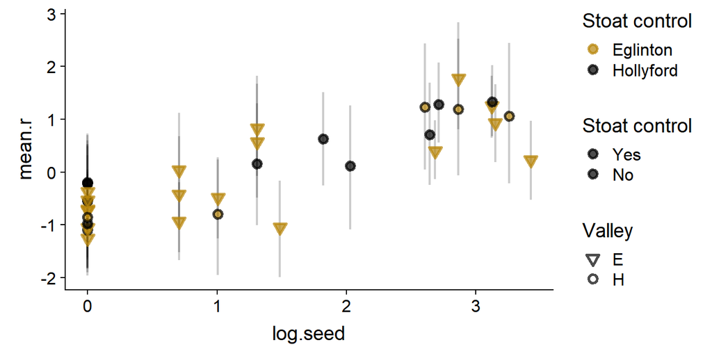

## All August data

### Autumn and Winter trends

- Rate of increase between Autumn and Winter
- (May and August rate of change)
- May mice abundace, seed and rat data

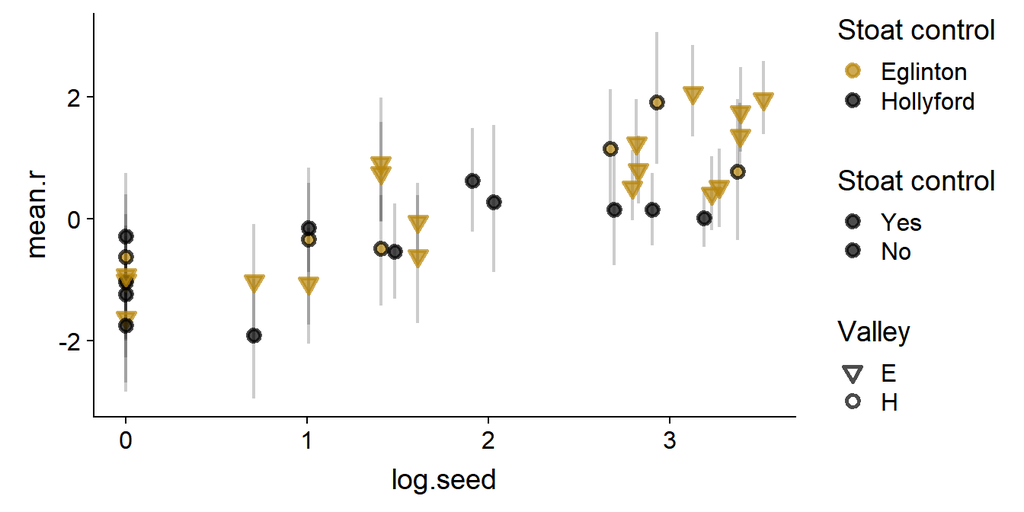

## All November data

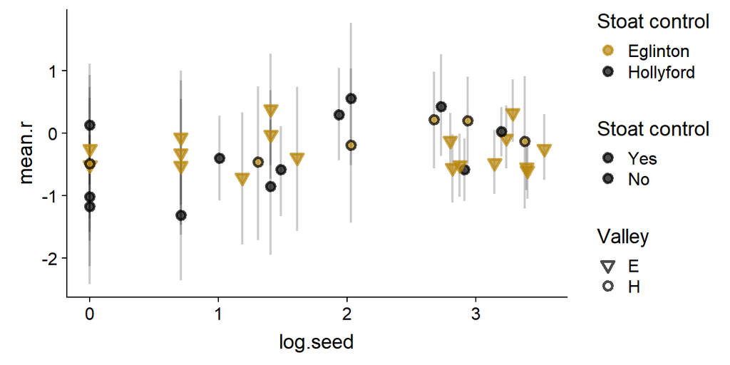

# Estimating lines

This is where it gets really tricky. I have done this in a way that works. I am sure there are better ways to code this but that is for a later date.

My steps are:

1. `out.final1` and filter out only month of interest
2. Find max values
- background points
2. `spread` data across the different parameter estimates
3. reduce the `out.full.136` to only `feb`
4. Merge with parameter dataset (steps1-2)
5. Plot away using `ggplot2`

## Seed

### All months

This is ok becuase the average estimates of line will all use the same average to estimate the trend line for each parameter and variable.

#### Fitted plot

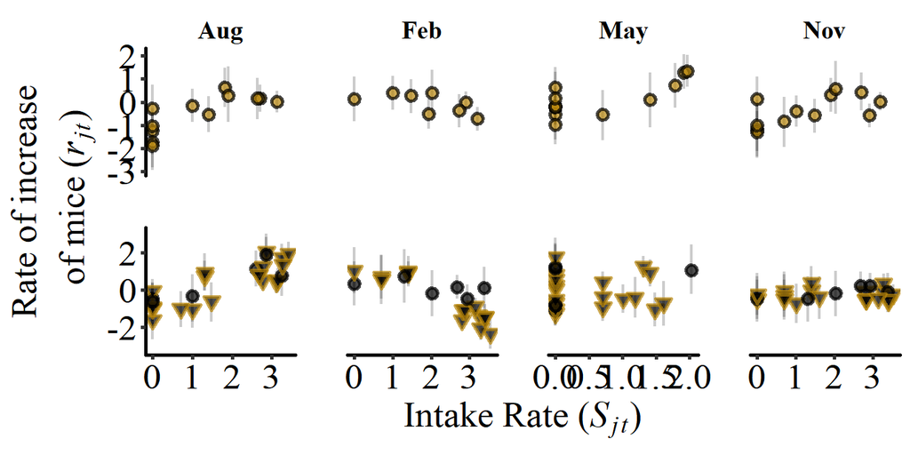

### August trend

This phase (Autumn to winter) has the strongest effect of `intake rate` on the population growth rates ($r_{jt}$).

## Density

### All months

#### Fitted plot

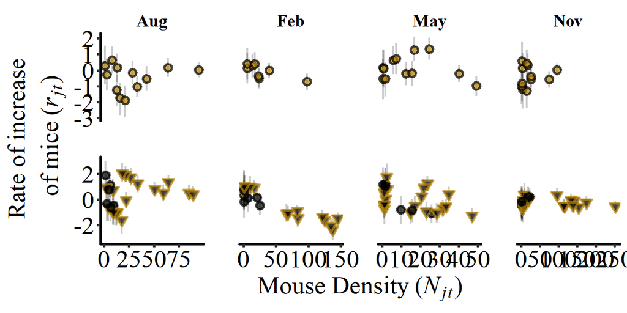

### February

#### Fitted plot

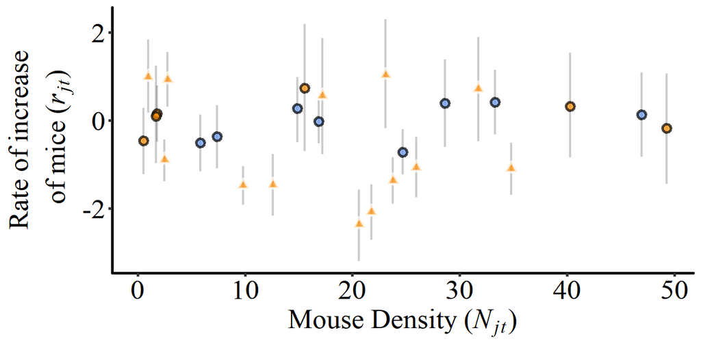

### May

#### Fitted plot

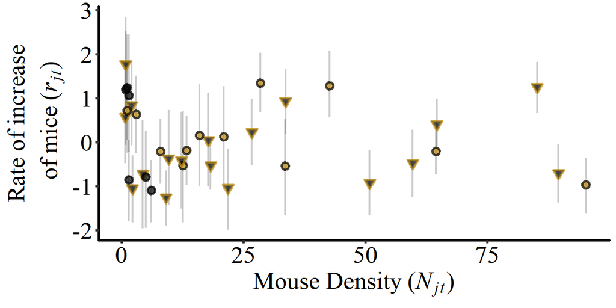

### Aug

#### Fitted plot

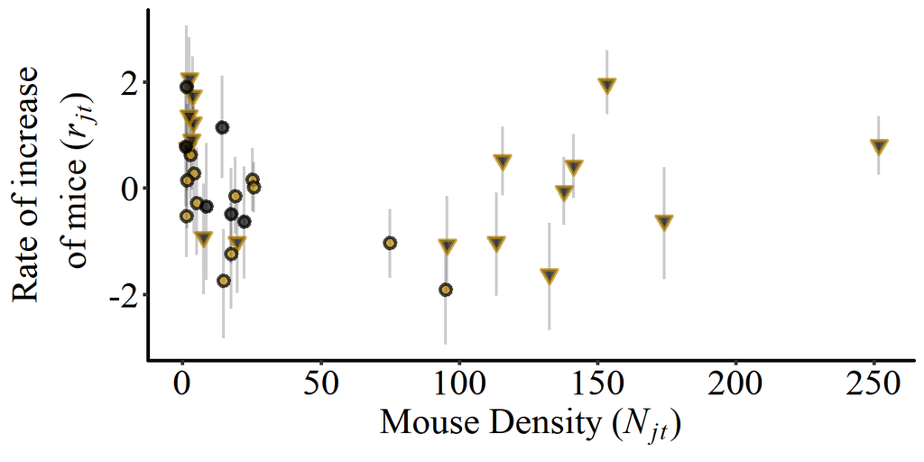

### Nov

#### Fitted plot

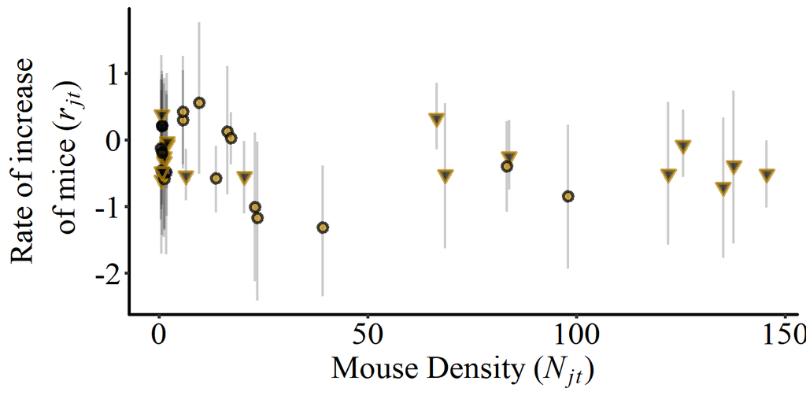

## Rats

### All months

#### Fitted plot

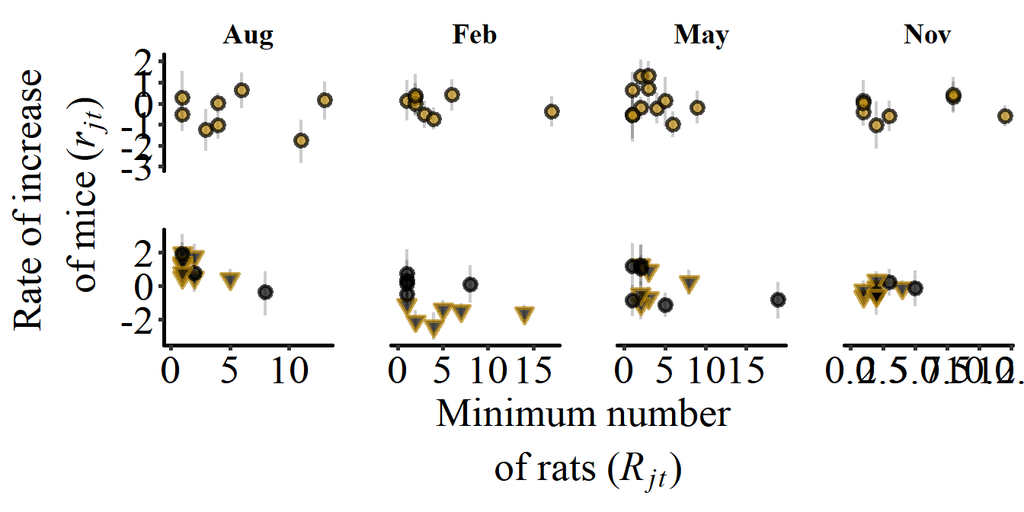

### February

### Fitted plot

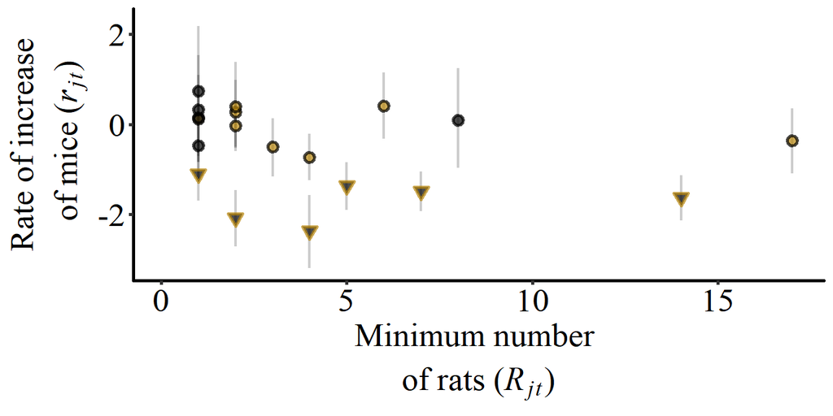

### Co-effiecents

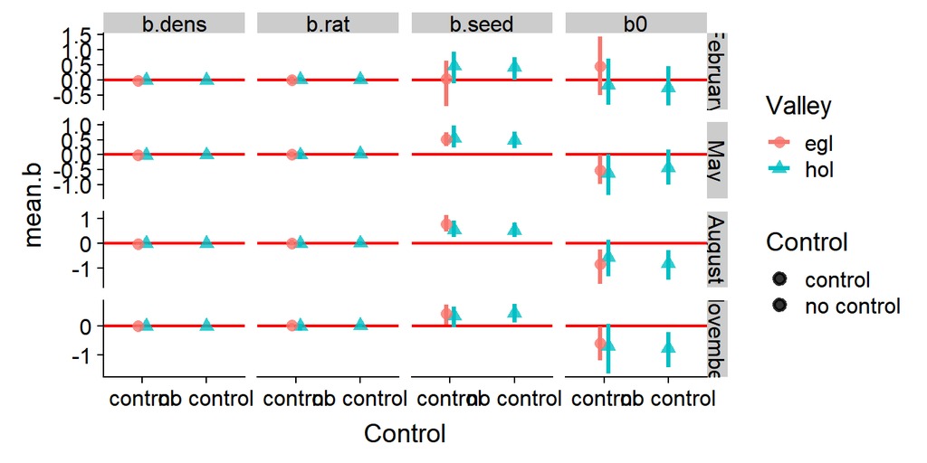

[figure not shown]

# Results

## Prediction C: Autumn and Winter trends

- Rate of increase between Autumn and Winter
- (May and August rate of change)
- May mice abundace, seed and rat data

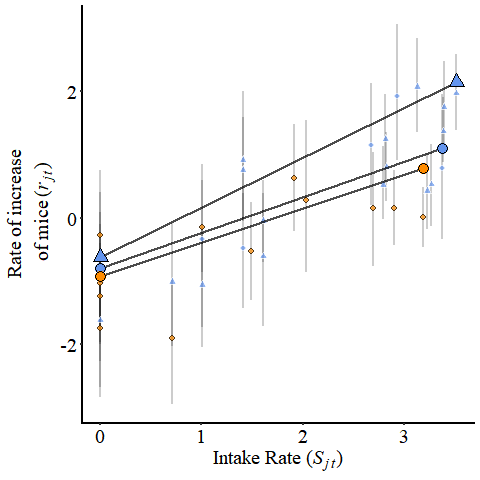

## Prediction D: Spring and Summer trends

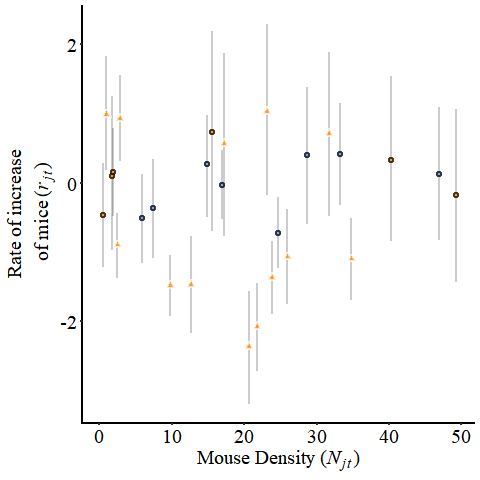

## Prediction E: Effect of rats

### Co-effiecents

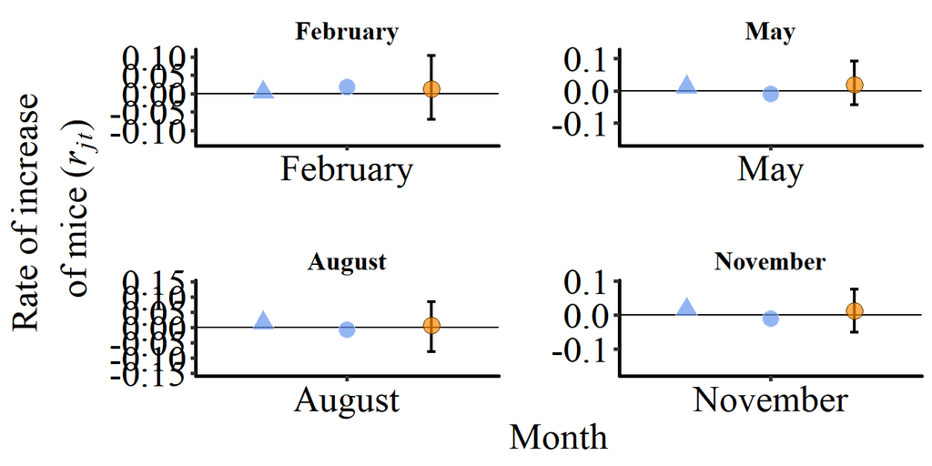

### Plot

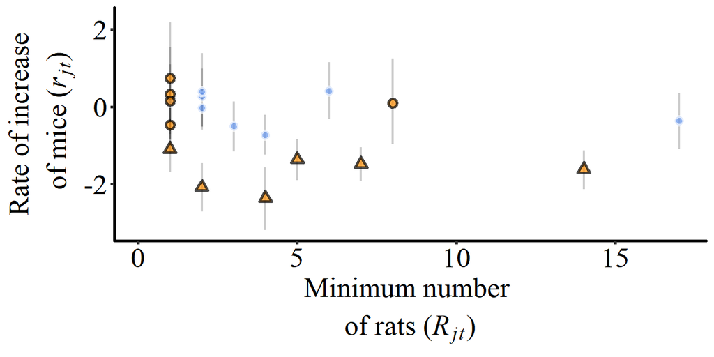

# Discussion

# Saving

## Saving

Must be `png`

# Appendix

# References